# Reproducing Holland’s nNIL HMM grid search with `caller_grid`

Author

Fausto Rodríguez-Zapata

Published

July 23, 2026

**NoteScope: an independent reimplementation of Holland’s grid, not a re-analysis of his CSV**

The companion foil (`nnil-calibration-foil`) decomposes Holland’s *published* grid (File_S04) to show the chip-supervised objective is driven by `nir`. This notebook instead **re-runs the entire 945-configuration grid** on the same real 24-line nNIL GBS, scored against the chip calls, through nilHMM’s unified `caller_grid()` kernel, and asks two questions: does our caller reproduce Holland’s result, and what is the marker-mismatch floor actually made of. Compute lives in the tracked scripts `scripts/nnil_foil/12_holland_grid.R` and `13_het_error_decomposition.R`; this notebook reads their outputs. Markers are on maize **v5** (`S<chr>_<pos_v5>`).

Zhong et al. (2025) calibrated the `nnil` caller with a **full-factorial grid search** over five HMM parameters (File_S04), picking the configuration that minimises the disagreement between the GBS calls and the chip calls on the 24 both-platform lines. We reproduced that search verbatim through `caller_grid()`, the unified emission-by-transition sweep kernel: for each of the 315 emission combinations we build the genotype emission once and batch the three-value `r` transition grid through the C++ Viterbi, scoring every configuration’s calls against the chip. The question this answers is whether our reimplemented caller lands on Holland’s optimum and his variance structure, and, since it does, what sets the residual ~2% mismatch that neither caller can beat.

```r
suppressMessages({
  library(data.table)
  library(ggplot2)
  library(patchwork)
  library(here)
  library(knitr)
})
FOIL <- here("data/nnil_foil")
theme_foil <- theme_classic(base_size = 10) +
  theme(
    text = element_text(family = "sans"),
    plot.tag = element_text(face = "bold"),
    legend.position = "top", legend.title = element_blank()
  )
col_ours <- "#0072B2" # caller_grid
col_holl <- "#D55E00" # Holland File_S04

rep <- fread(file.path(FOIL, "holland_grid_reproduction.csv")) # nir,germ,gert,p,r,mismatch,holland
sens <- fread(file.path(FOIL, "holland_grid_sensitivity.csv")) # param, ours, Holland
decomp <- fread(file.path(FOIL, "het_error_decomposition.csv")) # per-nir mismatch decomposition
conf <- fread(file.path(FOIL, "het_error_confusion.csv")) # V1=chip truth, V2=nnil call, N=genome fraction
f4 <- fread(here("agent/nNIL/File_S04.nNIL_gbs_vs_chip_data_HMMgridSearch.csv"))
params <- c("nir", "germ", "gert", "p", "r")
```

## 1. The grid: 945 = 7 × 3 × 3 × 5 × 3

Holland’s search is the **Cartesian product** of the sample points of five parameters. The grid size is simply the product of the per-parameter level counts, not a pairwise count:

$$\underbrace{7}_{\texttt{nir}}\times
\underbrace{3}_{\texttt{germ}}\times
\underbrace{3}_{\texttt{gert}}\times
\underbrace{5}_{\texttt{p}}\times
\underbrace{3}_{\texttt{r}}
= 945 .$$

```r
lv <- function(col) sort(unique(f4[[col]]))
roles <- c(
  nir = "emission non-informative rate (a donor-informative site emits no donor signal)",
  germ = "homozygote genotyping-error rate",
  gert = "heterozygote genotyping-error rate",
  p = "fraction of homozygous genotyping errors miscalled as heterozygous (the rest as the opposite homozygote)",
  r = "intermarker recombination fraction (transition / segment-length prior)"
)
levels_tab <- rbindlist(lapply(params, function(pp) {
  v <- lv(pp)
  data.table(
    parameter = pp, role = roles[[pp]], `n points` = length(v),
    `sample points` = paste(signif(v, 3), collapse = ", ")
  )
}))
levels_tab[, check := `n points`]
kable(levels_tab[, .(parameter, role, `n points`, `sample points`)],
  caption = sprintf(
    "The five swept parameters and their sample points. Product = %s = %d configurations.",
    paste(levels_tab$`n points`, collapse = " x "), prod(levels_tab$`n points`)
  )
)
```

The five swept parameters and their sample points. Product = 7 x 3 x 3 x 5 x 3 = 945 configurations.

| parameter | role | n points | sample points |
| --- | --- | --- | --- |
| nir | emission non-informative rate (a donor-informative site emits no donor signal) | 7 | 0.001, 0.01, 0.1, 0.3, 0.5, 0.7, 0.9 |
| germ | homozygote genotyping-error rate | 3 | 1e-04, 0.001, 0.01 |
| gert | heterozygote genotyping-error rate | 3 | 1e-04, 0.001, 0.01 |
| p | fraction of homozygous genotyping errors miscalled as heterozygous (the rest as the opposite homozygote) | 5 | 0.1, 0.25, 0.5, 0.75, 0.9 |
| r | intermarker recombination fraction (transition / segment-length prior) | 3 | 0.000234, 0.000469, 0.000937 |

## 2. `caller_grid` reproduces Holland’s grid

Running the same 945 configurations through `caller_grid()` and scoring against the chip reproduces File_S04 essentially exactly.

```r
pear <- cor(rep$mismatch, rep$holland)
spear <- cor(rep$mismatch, rep$holland, method = "spearman")
our_opt <- rep[which.min(mismatch)]
his_opt <- f4[which.min(mismatchMean)]
opt_tab <- rbind(
  data.table(source = "caller_grid (ours)", our_opt[, .(nir, germ, gert, p, r, mismatch = round(mismatch, 4))]),
  data.table(source = "Holland File_S04", his_opt[, .(nir, germ, gert, p, r, mismatch = round(mismatchMean, 4))])
)
kable(opt_tab, caption = sprintf(
  "Grid optima agree on the configuration. Per-configuration correlation across all 945: Pearson %.3f, Spearman %.3f.",
  pear, spear
))
```

Grid optima agree on the configuration. Per-configuration correlation across all 945: Pearson 1.000, Spearman 1.000.

| source | nir | germ | gert | p | r | mismatch |
| --- | --- | --- | --- | --- | --- | --- |
| caller_grid (ours) | 0.9 | 0.01 | 1e-04 | 0.9 | 0.0004686 | 0.0179 |
| Holland File_S04 | 0.9 | 0.01 | 1e-04 | 0.9 | 0.0004686 | 0.0007 |

The two grids pick the **same optimal configuration** (`nir` = 0.9, `germ` = 0.01, `gert` = 1e-4, `p` = 0.9, `r` = map value), and every configuration’s mismatch is in lockstep (Pearson `r` = 1). The variance decomposition of the objective matches too: `nir` carries essentially all of it under both callers.

```r
setnames(sens, old = names(sens), new = sub("ours \\(caller_grid\\)", "ours", names(sens)))
st <- copy(sens)
for (cc in setdiff(names(st), "param")) st[[cc]] <- sprintf("%.1f%%", 100 * st[[cc]])
kable(st, caption = "Variance share of the GBS-vs-chip mismatch attributed to each parameter (main-effects ANOVA), our caller_grid vs Holland's File_S04.")
```

Variance share of the GBS-vs-chip mismatch attributed to each parameter (main-effects ANOVA), our caller_grid vs Holland’s File_S04.

| param | Holland File_S04 | ours |
| --- | --- | --- |
| germ | 0.5% | 0.6% |
| gert | 0.0% | 0.0% |
| nir | 99.1% | 99.0% |
| p | 0.4% | 0.4% |
| r | 0.0% | 0.0% |

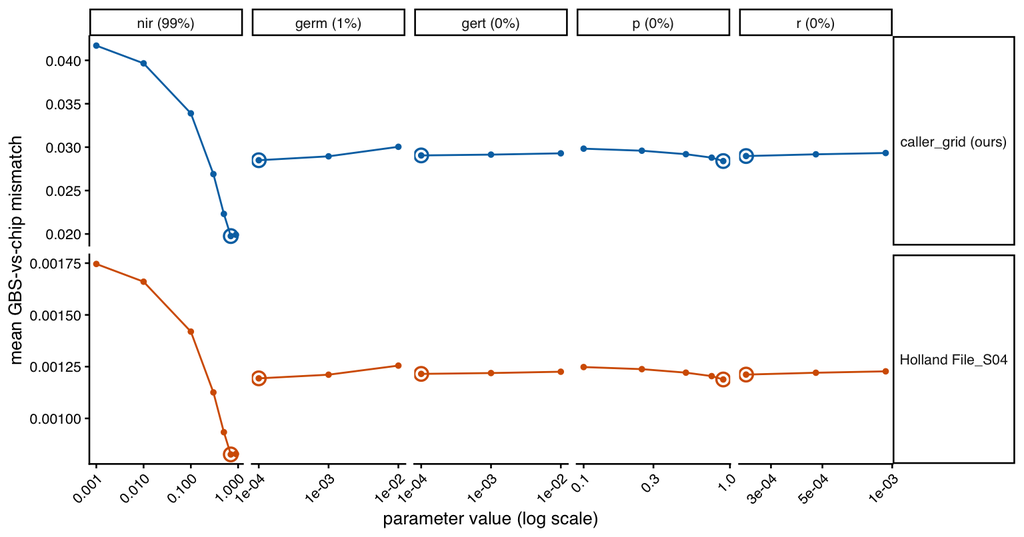

Figure 1: Marginal mean GBS-vs-chip mismatch versus each parameter (log x). Top row, our caller_grid; bottom row, Holland’s File_S04. Each ROW has its own y-scale, because the absolute floors differ (~1.8% vs ~0.07%); putting them on one axis would flatten Holland’s curve and hide the shape. On their own scales the two rows have the SAME shape and the SAME minimum location: a steep fall along nir to a minimum near nir = 0.9 (open circle marks each panel’s minimum), and near-flat responses along germ, gert, p, and r. Strip labels (top) give the parameter’s variance share in our grid.

```r
marg <- rbindlist(lapply(params, function(pp) {
  o <- rep[, .(mm = mean(mismatch)), by = c(pp)][, .(level = get(pp), mm, param = pp, src = "caller_grid (ours)")]
  h <- rep[, .(mm = mean(holland)), by = c(pp)][, .(level = get(pp), mm, param = pp, src = "Holland File_S04")]
  rbind(o, h)
}))
vshare <- setNames(sens[["ours"]], sens$param)
marg[, param := factor(param, levels = params, labels = sprintf("%s (%.0f%%)", params, 100 * vshare[params]))]
marg[, src := factor(src, levels = c("caller_grid (ours)", "Holland File_S04"))]
mins <- marg[, .SD[which.min(mm)], by = .(src, param)] # minimum per panel
ggplot(marg, aes(level, mm, colour = src)) +
  geom_line(linewidth = 0.5) +
  geom_point(size = 1.1) +
  geom_point(data = mins, shape = 21, size = 3, stroke = 0.9, fill = NA) +
  facet_grid(src ~ param, scales = "free") + # rows: source (own y); cols: parameter (own x)
  scale_x_log10() +
  scale_colour_manual(values = c("caller_grid (ours)" = col_ours, "Holland File_S04" = col_holl)) +
  labs(x = "parameter value (log scale)", y = "mean GBS-vs-chip mismatch") +
  theme_foil +
  theme(
    legend.position = "none", axis.text.x = element_text(angle = 45, hjust = 1),
    strip.text.y = element_text(angle = 0)
  )
```

### What the mismatch rate is, and why File_S04’s is ~24× smaller

We report the mismatch as **the fraction of ancestry-state calls that disagree with the chip: one value per cell of the (marker × NIL) matrix** — the ancestry state being recurrent (REF), heterozygous introgression (HET), or homozygous donor introgression (ALT). `nnil` ingests hard genotype calls but *outputs* these ancestry states, and the mismatch is between the GBS and chip ancestry calls. It is pooled over all 24 NILs and 11,310 shared markers (`1 - marker accuracy`, all states, including the >90% recurrent background). Our optimum is 0.0179 (~1.8%): about 18 of every 1000 ancestry-state calls differ from the chip.

Holland’s File_S04 `mismatchMean` at the same configuration is 0.0007 (~0.078%) — **the identical quantity divided by the number of lines.** In his grid code (`File_S16.py`, line 122) the per-line mismatch is `np.nanmean(NIL_vs_chip, axis = 1) / NIL_vs_chip.shape[0]`; since `np.nanmean(…, axis = 1)` is the per-line disagreement rate and `shape[0]` is the number of NILs (24), each value equals that rate divided by 24. So `mismatchMean` = our per-cell rate ÷ n_lines, and the ~24× we observe is exactly those 24 lines. Zhong et al. (2025) report this value (“mismatch rate of 0.0007”, “0.078%”) and describe it as a GBS-vs-chip “mismatch rate”; the two metrics differ only by this constant factor of n_lines.

This difference does not affect any of their conclusions: dividing every one of the 945 configurations by the same constant is monotone, so the optimum, the ranking, and the `nir`-dominance are identical (hence Pearson = 1.000, same `argmin`). Only the reported *magnitude* differs by the n_lines factor. We report the per-cell rate here so the value reads directly as an ancestry-call error rate; the next section asks what that ~1.8% floor is made of.

## 3. The ~2% marker-mismatch floor is donor-recall, not HET-calling error

A natural guess is that the floor is a heterozygote-calling-error minimum (spurious/dropped hets that no `nir` removes). It is not. Decomposing the chip vs nnil ancestry-state confusion at the optimum `nir` shows the mismatch is dominated by **REF↔︎ALT (recurrent vs homozygous-donor ancestry)** disagreement, with only about a quarter touching a HET call.

```r
d95 <- decomp[nir == 0.95]
floor_tab <- data.table(
  component = c("total mismatch", "REF<->ALT (donor recall)", "HET-involving"),
  `genome fraction` = round(c(d95$mismatch, d95$hom_hom, d95$het_involving), 4),
  `% of mismatch` = sprintf("%.0f%%", 100 * c(1, d95$hom_hom / d95$mismatch, d95$het_involving / d95$mismatch))
)
kable(floor_tab, caption = "Decomposition of the marker-mismatch floor at the optimum (nir = 0.95).")
```

Decomposition of the marker-mismatch floor at the optimum (nir = 0.95).

| component | genome fraction | % of mismatch |
| --- | --- | --- |
| total mismatch | 0.0175 | 100% |
| REF<->ALT (donor recall) | 0.0130 | 74% |
| HET-involving | 0.0046 | 26% |

```r
cw <- dcast(conf, V1 ~ V2, value.var = "N")
setnames(cw, "V1", "chip")
cw <- cw[match(c("REF", "HET", "ALT"), chip), .(chip, REF, HET, ALT)]
kable(cw, digits = 5, caption = "Chip vs nnil ancestry-state confusion at nir = 0.95 (genome fraction). Rows are the chip ancestry state, columns the nnil ancestry call; states are recurrent (REF), heterozygous introgression (HET), homozygous donor (ALT). The largest off-diagonal cell is chip-ALT called REF (donor under-recall).")
```

Chip vs nnil ancestry-state confusion at nir = 0.95 (genome fraction). Rows are the chip ancestry state, columns the nnil ancestry call; states are recurrent (REF), heterozygous introgression (HET), homozygous donor (ALT). The largest off-diagonal cell is chip-ALT called REF (donor under-recall).

| chip | REF | HET | ALT |
| --- | --- | --- | --- |
| REF | 0.94157 | 0.00171 | 0.00389 |
| HET | 0.00035 | 0.00054 | 0.00082 |
| ALT | 0.00906 | 0.00167 | 0.04037 |

The single largest error cell is **chip-ALT called REF** (0.0091): the caller misses roughly 0.9% of the genome the chip calls donor, calling it recurrent. That is a donor-recall / boundary-placement gap (the caller slightly under-fragments), not a het artifact. Removing every HET-involving disagreement still leaves ~1.3% per-cell mismatch: the floor is overwhelmingly donor-recall. So:

**ImportantThe het-error-floor hypothesis is refuted**

## Methods

`caller_grid()` (nilHMM, the unified `viterbi_sweep_cpp` kernel) runs the emission grid at the R level (one genotype-emission build per combination) and batches the transition (`r`) grid through the C++ Viterbi, reproducing a cold `call_ancestry()` at every configuration. The objective is the GBS-vs-chip **ancestry-call** mismatch rate: `1 - marker accuracy` over all ancestry-state calls (one value per (marker × NIL) cell), including the >90% recurrent background (`marker_dice`, `R/metrics.R`). Holland’s File_S04 reports this same rate divided by the number of lines (`File_S16.py:122` includes a per-line `/NIL_vs_chip.shape[0]`, = ÷24); the two are otherwise identical (Pearson 1.000). Grid run: `scripts/nnil_foil/12_holland_grid.R`; floor decomposition: `scripts/nnil_foil/13_het_error_decomposition.R`. Both read the same real 24-line GBS and chip calls as `08_nir_sweep.R`.